# Clase 3: Geoservicios y Open StreetMap

Analisis espacial con R

Martín Alalú

## 0.1 Geoservicios

Uno de los modos más útiles para acceder y descargar información geográfica es a través de WFS (Web Feature Service), un servicio estándar que ofrece una interfaz de comunicación que permite interactuar con los objetos geográficos. La mayoría de los institutos geográficos del mundo o entidades que producen información geográfica disponibilizan sus datos a través de este tipo de servicios ya que es un estándar en la industria.

A través de estos Geoservicios se puede ver todo el catálogo de datos disponible de un modo muy rápido y fácil y descargarse el deseado directamente desde R (o cualquier lenguaje de programación).

El [Instituto Geográfico Nacional](https://www.ign.gob.ar/NuestrasActividades/InformacionGeoespacial/ServiciosOGC) e [INDEC](https://geoservicios.indec.gov.ar/nomenclador-vias-de-circulacion/?contenido=descargas) tienen sus geoservicios (con cobertura en todo el país). IDERA (Infraestructura de Datos Espaciales de la República Argentina) publica [una lista](https://www.idera.gob.ar/index.php?option=com_content&view=article&id=335:geoservicios&catid=33&Itemid=169) con todos los geoservicios disponibles de las entidades públicas (ministerios nacionales, provincias y municipios).

La librería **sf** nos va a ayudar a consultar los WFS de un modo muy fácil a través de la función st_layers en la que tenemos que pasar como parámetro el tipo de geoservicio (WFS en este caso) seguida por la URL donde se encuentra disponible.

Veamos qué capas tiene disponible el INDEC

```r
library(sf)
library(tidyverse)

indec <- st_layers("WFS:https://geoservicios.indec.gob.ar/geoserver/wfs?getcapabilities")
indec$name
```

```
##  [1] "geocenso2010:actividad_dpto"
##  [2] "geocenso2010:actividad_pcia"
##  [3] "geocenso2010:actividad_radio"
##  [4] "sig:v_departamentos"
##  [5] "geocenso2010:departamentos_codigo"
##  [6] "geocenso2010:hogares_con_agua_red_dpto"
##  [7] "geocenso2010:hogares_con_agua_red_pcia"
##  [8] "geocenso2010:hogares_con_agua_red_radio"
##  [9] "geocenso2010:hogares_con_desague_cloacal_dpto"
## [10] "geocenso2010:hogares_con_desague_cloacal_pcia"
## [11] "geocenso2010:hogares_con_desague_cloacal_radio"
## [12] "geocenso2010:hogares_con_red_gas_dpto"
## [13] "geocenso2010:hogares_con_red_gas_pcia"
## [14] "geocenso2010:hogares_con_gas_de_red_radio"
## [15] "geocenso2010:hacinamiento_dpto"
```

[output cut: 41 more lines]

Tenemos 56 capas disponibles! Si queremos descargarnos una de las capas necesitamos usar la ya conocida función **st_read** y en el parámetro le tenemos que pasar la url donde se encuentra la capa deseada.

Esta URL se compone de 2 partes: * url_base: es la URL principal donde se encuentra el geoservicio, incluidos ya los parámetros para indicar que queremos descargarnos una capa. * capa_wfs: nombre de la capa que queremos descargar tal como está en el listado.

Entonces si por ejemplo queremos descargar la capa “geocenso2010:nbi_radio” que tal como su nombre lo indica tiene el NBI a nivel radio censal según el Censo 2010…

```r
baseurl <- "https://geoservicios.indec.gob.ar/geoserver/wfs?request=GetFeature&service=WFS&typeName="
capa_wfs <- "geocenso2010:nbi_radio"

nbi_radios <- st_read(paste0(baseurl,capa_wfs))
```

Excelente! Nos descargó la capa, tiene 52.379 registros! Veamos qué class es y algunos registros.

```r
class(nbi_radios)
```

```
## [1] "sf"         "data.frame"
```

```r
head(nbi_radios)
```

```
## Simple feature collection with 6 features and 8 fields
## Geometry type: MULTISURFACE
## Dimension:     XY
## Bounding box:  xmin: 4192600 ymin: 6143535 xmax: 4196994 ymax: 6150759
## CRS:           NA
##                                      gml_id      link personas_con_nbi
## 1 nbi_radio.fid--76d2beb4_17ac13b3042_-5fd3 020060903               11
## 2 nbi_radio.fid--76d2beb4_17ac13b3042_-5fd2 020130809                9
## 3 nbi_radio.fid--76d2beb4_17ac13b3042_-5fd1 020132001                0
## 4 nbi_radio.fid--76d2beb4_17ac13b3042_-5fd0 020132304                0
## 5 nbi_radio.fid--76d2beb4_17ac13b3042_-5fcf 020140905                8
## 6 nbi_radio.fid--76d2beb4_17ac13b3042_-5fce 020142804                8
##   personas_con_nbi_porc total_pob hogares_con_nbi hogares_con_nbi_porc
## 1                   1.7       653               3                  1.0
## 2                   1.3       708               3                  0.9
## 3                   0.0       646               0                  0.0
## 4                   0.0       604               0                  0.0
## 5                   2.0       398               2                  1.0
## 6                   1.2       693               2                  0.6
##   total_hog                           geom
## 1       293 MULTISURFACE (POLYGON ((419...
## 2       326 MULTISURFACE (POLYGON ((419...
## 3       301 MULTISURFACE (POLYGON ((419...
## 4       294 MULTISURFACE (POLYGON ((419...
## 5       198 MULTISURFACE (POLYGON ((419...
## 6       314 MULTISURFACE (POLYGON ((419...
```

Genial. Antes de ir al mapa nos damos cuenta que no tenemos ninguna columna que nos permita saber de qué provincia o localidad es cada registro, sólo tenemos la columna “link” que es el identificador único del radio censal.

El valor de “link” a nivel radio es una concatenación de: codigo_provincia + codigo_departamento + codigo_fraccion_censal + codigo_radio_censal

O sea que para joinear el nombre de la provincia y la localidad vamos a necesitar descargarnos 3 archivos más disponibles en el geoservicio:

- geocenso2010:radios_codigo: Contiene el id del radio (link) y los id de provincia y localidad.
- sig:v_departamentos: Para cada id de departamento tenemos un nombre.
- sig:v_provincias: Id y nombre de las 24 provincias

```r
wfs_radios_codigo <- "geocenso2010:radios_codigo"
wfs_deptos <- "sig:v_departamentos"
wfs_prov <- "sig:v_provincias"

radios_codigo <- st_read(paste0(baseurl,wfs_radios_codigo ))
deptos <- st_read(paste0(baseurl,wfs_deptos))
prov <- st_read(paste0(baseurl,wfs_prov))
```

Veamos qué tenemos.

```r
head(radios_codigo)
```

```
## Simple feature collection with 6 features and 8 fields
## Geometry type: MULTISURFACE
## Dimension:     XY
## Bounding box:  xmin: 4192600 ymin: 6143535 xmax: 4196994 ymax: 6150759
## CRS:           NA
##                                        gml_id      link tipo codpcia coddpto
## 1 radios_codigo.fid--76d2beb4_17ac13c9dc0_636 020060903    U      02     006
## 2 radios_codigo.fid--76d2beb4_17ac13c9dc0_637 020130809    U      02     013
## 3 radios_codigo.fid--76d2beb4_17ac13c9dc0_638 020132001    U      02     013
## 4 radios_codigo.fid--76d2beb4_17ac13c9dc0_639 020132304    U      02     013
## 5 radios_codigo.fid--76d2beb4_17ac13c9dc0_63a 020140905    U      02     014
## 6 radios_codigo.fid--76d2beb4_17ac13c9dc0_63b 020142804    U      02     014
##   fraccion radio color_psid                           geom
## 1       09    03          2 MULTISURFACE (POLYGON ((419...
## 2       08    09          3 MULTISURFACE (POLYGON ((419...
## 3       20    01          2 MULTISURFACE (POLYGON ((419...
## 4       23    04          2 MULTISURFACE (POLYGON ((419...
## 5       09    05          1 MULTISURFACE (POLYGON ((419...
## 6       28    04          2 MULTISURFACE (POLYGON ((419...
```

radios_codigo tiene la columna link y luego un id de provincia y otro de departamento. Estas columnas las podemos agregar a nuestro de df de nbi ya que también tiene la columna link.

Hagamos un left_join!

```r
# nbi_radios <- left_join(nbi_radios, radios_codigo, by = "link")
```

¿Qué pasó? No nos deja hacer un left_join ya que estamos usando objetos espaciales (sf) entonces nos obliga a hacer un spatial_join (st_join).

Pero nosotros no queremos unir estos sf a través de su relación geográfica sino por tener una columna en común! Entonces lo que tenemos que hacer es pasar los sf a dataframe (que dejen de ser geográficos), hacer el left_join (entre dos dataframes) y luego reestablecer su geometría, que vuelvan a ser df.

```r
#Pasamos los objetos de sf a dataframe
nbi_radios <- as.data.frame(nbi_radios)
radios_codigo <- as.data.frame(radios_codigo)

#Chequeamos qué clase de objeto es
class(nbi_radios)
```

```
## [1] "data.frame"
```

```r
class(radios_codigo)
```

```
## [1] "data.frame"
```

```r
#Left join
nbi_radios <- left_join(nbi_radios, radios_codigo, by = "link")
```

Como tenemos que seguir joineando todavía para tener el nombre del departamento y provincia de cada radio censal antes de reestablecer la geometría a nbi_radios vamos a seguir avanzando y ver qué tiene el dataframe deptos.

```r
head(deptos)
```

```
## Simple feature collection with 6 features and 8 fields
## Geometry type: MULTIPOLYGON
## Dimension:     XY
## Bounding box:  xmin: 3217870 ymin: 473.835 xmax: 5670707 ymax: 7175624
## CRS:           NA
##                                            gml_id                 nombre desde
## 1 v_departamentos.fid--76d2beb4_17ac13d48f8_-28f3                Federal  <NA>
## 2 v_departamentos.fid--76d2beb4_17ac13d48f8_-28f2    Antártida Argentina  <NA>
## 3 v_departamentos.fid--76d2beb4_17ac13d48f8_-28f1             Avellaneda  <NA>
## 4 v_departamentos.fid--76d2beb4_17ac13d48f8_-28f0 Rosario de la Frontera  <NA>
## 5 v_departamentos.fid--76d2beb4_17ac13d48f8_-28ef    San Luis del Palmar  <NA>
## 6 v_departamentos.fid--76d2beb4_17ac13d48f8_-28ee              Río Chico  <NA>
##   hasta estilo_id  link fuente_id toponimo_id                       the_geom
## 1  <NA>         4 30035         4      104993 MULTIPOLYGON (((4212116 658...
## 2  <NA>         4 94028         4      104982 MULTIPOLYGON (((3365940 101...
## 3  <NA>         3 06035         4      106606 MULTIPOLYGON (((4203736 614...
## 4  <NA>         4 66140         4      104988 MULTIPOLYGON (((3678332 715...
## 5  <NA>         4 18140         4      105797 MULTIPOLYGON (((4252986 694...
## 6  <NA>         4 90077         4      105798 MULTIPOLYGON (((3503680 696...
```

Deptos tiene una columna con el nombre del departamento y otra que también se llama link. Pero aca vemos que link es un número mas corto, eso es así porque en este caso el link está solo compuesto por: codigo_provincia + codigo_departamento.

Entonces para poder hacer un left_join con nbi_radios necesitamos crear una columna nueva que tenga esa misma combinación. Vamos a llamar a esta nueva columna como prov_depto.

```r
nbi_radios$prov_depto <- paste0(nbi_radios$codpcia, nbi_radios$coddpto)
```

Ahora sí, pasamos deptos a dataframe y luego joineamos.

```r
deptos <- as.data.frame(deptos)

class(deptos)
```

```
## [1] "data.frame"
```

```r
#Left join
nbi_radios <- left_join(nbi_radios, deptos, by = c("prov_depto"="link"))
```

Excelente! Ahora solo nos queda joinear para tener el nombre de la provincia.

```r
head(prov)
```

```
## Simple feature collection with 6 features and 8 fields
## Geometry type: MULTIPOLYGON
## Dimension:     XY
## Bounding box:  xmin: 3068202 ymin: 473.835 xmax: 5670707 ymax: 7566774
## CRS:           NA
##                                         gml_id
## 1 v_provincias.fid--76d2beb4_17ac13d48f8_-26b3
## 2 v_provincias.fid--76d2beb4_17ac13d48f8_-26b2
## 3 v_provincias.fid--76d2beb4_17ac13d48f8_-26b1
## 4 v_provincias.fid--76d2beb4_17ac13d48f8_-26b0
## 5 v_provincias.fid--76d2beb4_17ac13d48f8_-26af
## 6 v_provincias.fid--76d2beb4_17ac13d48f8_-26ae
##                                                  nombre desde hasta estilo_id
## 1 Tierra del Fuego, Antártida e Islas del Atlántico Sur  <NA>  <NA>         1
## 2                                                 Salta  <NA>  <NA>         1
## 3                                               Córdoba  <NA>  <NA>         1
## 4                                              Misiones  <NA>  <NA>         1
## 5                                              San Juan  <NA>  <NA>         1
## 6                                              San Luis  <NA>  <NA>         1
##   link fuente_id toponimo_id                       the_geom
## 1   94         4       25864 MULTIPOLYGON (((3336851 103...
## 2   66         4          99 MULTIPOLYGON (((3605468 709...
## 3   14         4       69672 MULTIPOLYGON (((3739478 617...
## 4   54         4       69673 MULTIPOLYGON (((4554966 686...
## 5   70         4       56321 MULTIPOLYGON (((3281509 644...
## 6   74         4       56322 MULTIPOLYGON (((3580722 616...
```

Como era esperable aca el link es el id de la provincia. Vamos al join entonces.

```r
prov <- as.data.frame(prov)

class(prov)
```

```
## [1] "data.frame"
```

```r
#Left join
nbi_radios <- left_join(nbi_radios, prov, by = c("codpcia"="link"))

colnames(nbi_radios)
```

```
##  [1] "gml_id.x"              "link"                  "personas_con_nbi"
##  [4] "personas_con_nbi_porc" "total_pob"             "hogares_con_nbi"
##  [7] "hogares_con_nbi_porc"  "total_hog"             "geom.x"
## [10] "gml_id.y"              "tipo"                  "codpcia"
## [13] "coddpto"               "fraccion"              "radio"
## [16] "color_psid"            "geom.y"                "prov_depto"
## [19] "gml_id.x.x"            "nombre.x"              "desde.x"
## [22] "hasta.x"               "estilo_id.x"           "fuente_id.x"
## [25] "toponimo_id.x"         "the_geom.x"            "gml_id.y.y"
## [28] "nombre.y"              "desde.y"               "hasta.y"
## [31] "estilo_id.y"           "fuente_id.y"           "toponimo_id.y"
## [34] "the_geom.y"
```

Listo! Vamos a seleccionar solo las columnas que nos interesan asi queda más limpio el dataframe.

```r
nbi_radios <- nbi_radios %>%
              select(link, #id del radio censal
                     nombre.x, #nombre del departamento
                     nombre.y, #nombre de la provincia
                     personas_con_nbi,
                     personas_con_nbi_porc,
                     total_pob,
                     hogares_con_nbi,
                     hogares_con_nbi_porc,
                     total_hog,
                     geom.x #geometria
              ) %>%
              rename(departamento = nombre.x,
                     provincia = nombre.y)
```

Y ahora sí reestablecemos la geometría con la función **st_sf**.

```r
nbi_radios  <-  st_sf(nbi_radios, sf_column_name = 'geom.x')
class(nbi_radios)
```

```
## [1] "sf"         "data.frame"
```

Por último al mapa! Veamos como se distribuye el porcentaje de hogares con nbi en la provincia de Córdoba.

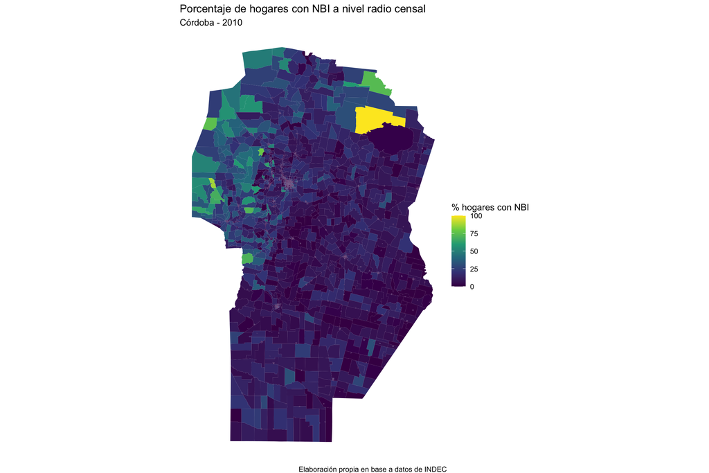

```r
cordoba_nbi <- filter(nbi_radios, provincia == "Córdoba")

ggplot() +
  geom_sf(data = cordoba_nbi, aes(fill = hogares_con_nbi_porc), color = NA) +
  scale_fill_viridis_c() +
  theme_void() +
  labs(title = "Porcentaje de hogares con NBI a nivel radio censal",
       subtitle = "Córdoba - 2010",
       fill = "% hogares con NBI",
       caption = "Elaboración propia en base a datos de INDEC")
```

## 0.2 Open Street Map: la wiki de mapas

OpenStreetMap es una de las comunidades geoespaciales más importantes a través de la cual todos podemos aportar información espacial del lugar que querramos, es algo asi como la versión de mapas de Wikipedia. Al ser una iniciativa basada en la colaboración tiene una fuerte política de apertura de datos, por lo que todos sus datos se pueden consultar y descargar libremente!

Probemos descargarnos las plazas de Villa Allende, Córdoba. La librería que nos va a facilitar el acceso a los datos es **osmdata**. Lo primero que tenemos que hacer es construir nuestro bounding box, es decir especificar de qué coordenadas queremos los datos. Para eso usamos la función **getbb**, en la que le tenemos que pasar el nombre exacto del lugar que buscamos.

```r
library(osmdata)

bbox <- getbb("Villa Allende, Córdoba")
bbox
```

```
##         min       max
## x -64.32480 -64.22095
## y -31.30846 -31.26487
```

Pefecto. Tenemos los límites. La función **getbb** también permite extraer el polígono de un área en formato sf, para eso sólo le tenemos que indicar el formato de salida.

```r
allende_poly <- getbb("Municipio de Villa Allende, Córdoba", format_out = "sf_polygon")
class(allende_poly)
```

```
## [1] "sf"         "data.frame"
```

Ahora lo siguiente es construir la consulta a la base de datos de Open Street Map en la que le indicamos que queremos descargarnos las plazas de Villa Allende. La función es opq, que tiene como parámetro el bounding box y luego le tenemos que agregar los objetos que queremos extraer, lo cual hacemos con add_osm_feature indicando la key que queremos consultar.

Para ver cómo están catálogados cada uno de los objetos de OSM pueden ver su [Wiki](https://wiki.openstreetmap.org/wiki/ES:).

```r
allende <- opq(bbox) %>%
    add_osm_feature(key = "leisure", value = "park")

allende
```

```
## $bbox
## [1] "-31.308457,-64.3248015,-31.2648675,-64.2209538"
##
## $prefix
## [1] "[out:xml][timeout:25];\n(\n"
##
## $suffix
## [1] ");\n(._;>;);\nout body;"
##
## $features
## [1] " [\"leisure\"=\"park\"]"
##
## attr(,"class")
## [1] "list"           "overpass_query"
## attr(,"nodes_only")
## [1] FALSE
```

Y ahora hacemos la consulta a la base de datos propiamente dicha con **osmdata_sf**.

```r
allende <- allende %>%
    osmdata_sf()

allende
```

Y nos quedamos con los polígonos de la respuesta a la consulta que hicimos.

```r
allende_plazas <- allende$osm_polygons

head(allende_plazas)
```

```
## Simple feature collection with 6 features and 4 fields
## Geometry type: POLYGON
## Dimension:     XY
## Bounding box:  xmin: -64.29822 ymin: -31.30823 xmax: -64.25372 ymax: -31.29313
## Geodetic CRS:  WGS 84
##              osm_id                        name addr.city leisure
## 154244319 154244319                        <NA>      <NA>    park
## 268203974 268203974                        <NA>      <NA>    park
## 304681475 304681475 Plaza Gral. Manuel Belgrano      <NA>    park
## 304681480 304681480                        <NA>      <NA>    park
## 409557769 409557769                        <NA>      <NA>    park
## 409557772 409557772                        <NA>      <NA>    park
##                                 geometry
## 154244319 POLYGON ((-64.25701 -31.304...
## 268203974 POLYGON ((-64.28701 -31.307...
## 304681475 POLYGON ((-64.29793 -31.293...
## 304681480 POLYGON ((-64.27381 -31.302...
## 409557769 POLYGON ((-64.28504 -31.295...
## 409557772 POLYGON ((-64.28619 -31.297...
```

Listo! Ahora podemos hacer un mapa.

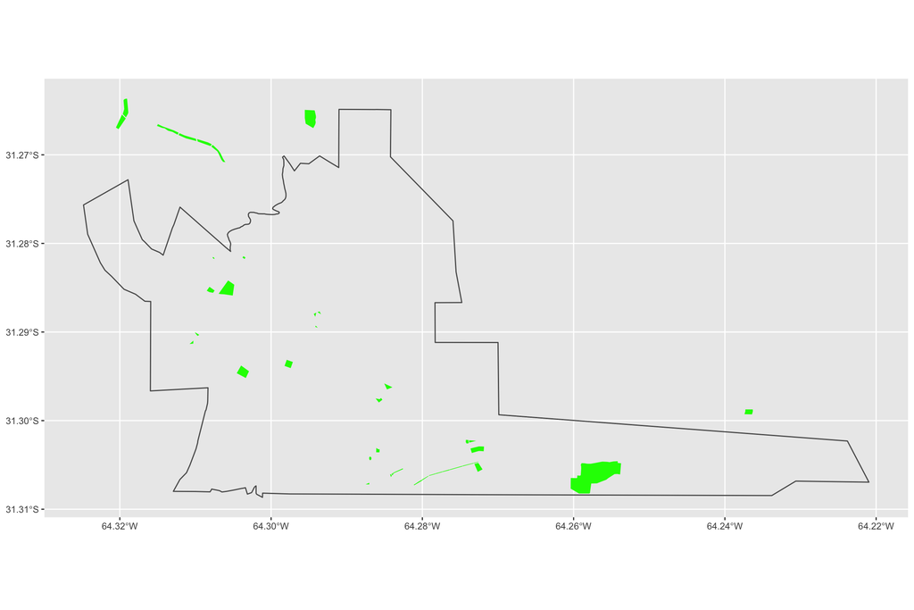

```r
ggplot() +
    geom_sf(data=allende_poly, fill = NA) +
    geom_sf(data = allende_plazas, fill = "green", color = NA)
```

Quedaron plazas afuera de los límites de Villa Allende! Eso ocurre porque la consulta de las plazas la hicimos con todo el recuardo (bounding box) y no sólo con los límites exatos. Pero fácilmente las podemos filtrar usando **st_intersection**!

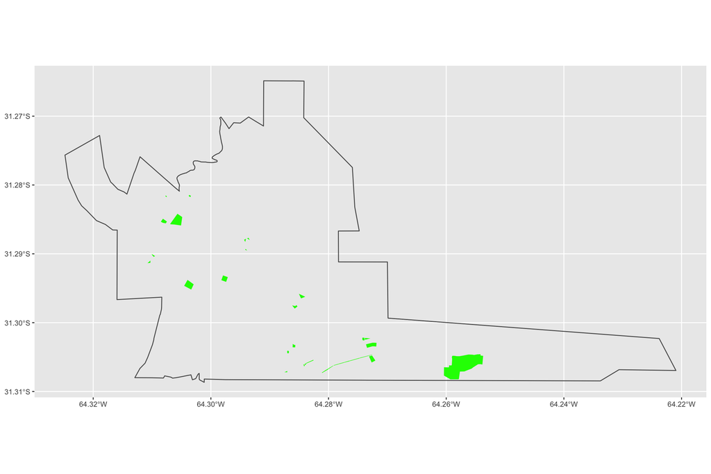

```r
allende_plazas_limite <- st_intersection(allende_plazas, allende_poly)

ggplot() +
    geom_sf(data=allende_poly, fill = NA) +
    geom_sf(data = allende_plazas_limite, fill = "green", color = NA)
```